# Exploratory Data Analysis - Clothing Reviews

Atika Dewi Suryani

July 2, 2020

# 1 Background

Hi, we will **study data** that i got from my course

```r
# clear-up the environment
rm(list = ls())

# chunk options
knitr::opts_chunk$set(
  message = FALSE,
  warning = FALSE,
  fig.align = "center",
  comment = "#>"
)

# scientific notation
options(scipen = 9999)
```

```r
# import libs
# if there are libraries are required
```

# 2 Data Study

## 2.1 Input Data

Make sure our data placed in the same folder our R project data

```r
# read data
clothing <- read.csv("data/clothing_reviews.csv")
```

**Data is ready then we can get started**

# 3 Data Inspection

```r
# check 5 data above
head(clothing)
```

|  | clothing_id | age_group | rating | recommended_ind | positive_feedback_count | division_name | category | review_date |
| --- | --- | --- | --- | --- | --- | --- | --- | --- |
| 1 | 767 | 25 to 34 | 4 | 1 | 0 | Initmates | Intimate | 30/03/2017 |
| 2 | 1080 | 25 to 34 | 5 | 1 | 4 | General | Dresses | 10/3/17 |
| 3 | 1077 | 55 to 64 | 3 | 0 | 0 | General | Dresses | 4/3/17 |
| 4 | 1049 | 35 to 54 | 5 | 1 | 0 | General Petite | Bottoms | 3/3/17 |
| 5 | 847 | 35 to 54 | 5 | 1 | 6 | General | Tops | 14/12/2017 |
| 6 | 1080 | 35 to 54 | 2 | 0 | 4 | General | Dresses | 8/9/17 |

```r
# check 5 data below
tail(clothing)
```

|  | clothing_id | age_group | rating | recommended_ind | positive_feedback_count | division_name | category | review_date |
| --- | --- | --- | --- | --- | --- | --- | --- | --- |
| 23481 | 862 | 35 to 54 | 5 | 1 | 0 | General Petite | Tops | 26/05/2018 |
| 23482 | 1104 | 25 to 34 | 5 | 1 | 0 | General Petite | Dresses | 26/05/2018 |
| 23483 | 862 | 35 to 54 | 3 | 1 | 0 | General Petite | Tops | 26/05/2018 |
| 23484 | 1104 | 25 to 34 | 3 | 0 | 1 | General Petite | Dresses | 26/05/2018 |
| 23485 | 1084 | 25 to 34 | 3 | 1 | 2 | General | Dresses | 26/05/2018 |
| 23486 | 1104 | 35 to 54 | 5 | 1 | 22 | General Petite | Dresses | 26/05/2018 |

```r
# check shape of datas
dim(clothing)
```

```
#> [1] 23486     8
```

```r
# check data NA
colSums(is.na(clothing))
```

```
#>             clothing_id               age_group                  rating
#>                       0                       0                       0
#>         recommended_ind positive_feedback_count           division_name
#>                       0                       0                      14
#>                category             review_date
#>                      14                       0
```

Check for missing value

```r
# remove missing data
# import library
library(tidyverse)
clothing <- clothing %>%
  drop_na(division_name, category)

colSums(is.na(clothing))
```

```
#>             clothing_id               age_group                  rating
#>                       0                       0                       0
#>         recommended_ind positive_feedback_count           division_name
#>                       0                       0                       0
#>                category             review_date
#>                       0                       0
```

```r
# describe column names
names(clothing)
```

```
#> [1] "clothing_id"             "age_group"
#> [3] "rating"                  "recommended_ind"
#> [5] "positive_feedback_count" "division_name"
#> [7] "category"                "review_date"
```

# 4 Data Cleansing and Coertions

Check data type for each column

```r
str(clothing)
```

```
#> 'data.frame':    23472 obs. of  8 variables:
#>  $ clothing_id            : int  767 1080 1077 1049 847 1080 858 858 1077 1077 ...
#>  $ age_group              : Factor w/ 5 levels "18 to 24","25 to 34",..: 2 2 4 3 3 3 3 3 1 2 ...
#>  $ rating                 : int  4 5 3 5 5 2 5 4 5 5 ...
#>  $ recommended_ind        : int  1 1 0 1 1 0 1 1 1 1 ...
#>  $ positive_feedback_count: int  0 4 0 0 6 4 1 4 0 0 ...
#>  $ division_name          : Factor w/ 3 levels "General","General Petite",..: 3 1 1 2 1 1 2 2 1 1 ...
#>  $ category               : Factor w/ 6 levels "Bottoms","Dresses",..: 3 2 2 1 5 2 5 5 2 2 ...
#>  $ review_date            : Factor w/ 320 levels "1/11/17","1/12/15",..: 237 15 257 223 52 310 11 208 166 59 ...
```

**From this result, we find some of data type not in the correct type. we need to convert it into corect type (data coertion)**

```r
# change data type
clothing$review_date <- as.Date(clothing$review_date, "%y/%m/%d")
clothing$age_group <- as.character(clothing$age_group)
clothing$positive_feedback_count <- as.numeric(clothing$positive_feedback_count)


str(clothing)
```

```
#> 'data.frame':    23472 obs. of  8 variables:
#>  $ clothing_id            : int  767 1080 1077 1049 847 1080 858 858 1077 1077 ...
#>  $ age_group              : chr  "25 to 34" "25 to 34" "55 to 64" "35 to 54" ...
#>  $ rating                 : int  4 5 3 5 5 2 5 4 5 5 ...
#>  $ recommended_ind        : int  1 1 0 1 1 0 1 1 1 1 ...
#>  $ positive_feedback_count: num  0 4 0 0 6 4 1 4 0 0 ...
#>  $ division_name          : Factor w/ 3 levels "General","General Petite",..: 3 1 1 2 1 1 2 2 1 1 ...
#>  $ category               : Factor w/ 6 levels "Bottoms","Dresses",..: 3 2 2 1 5 2 5 5 2 2 ...
#>  $ review_date            : Date, format: "2030-03-20" "2010-03-17" ...
```

Now, the data is ready to be procces and analyse

# 5 Data Explanation

```r
summary(clothing)
```

```
#>   clothing_id      age_group             rating      recommended_ind
#>  Min.   :   0.0   Length:23472       Min.   :1.000   Min.   :0.0000
#>  1st Qu.: 861.0   Class :character   1st Qu.:4.000   1st Qu.:1.0000
#>  Median : 936.0   Mode  :character   Median :5.000   Median :1.0000
#>  Mean   : 918.5                      Mean   :4.196   Mean   :0.8223
#>  3rd Qu.:1078.0                      3rd Qu.:5.000   3rd Qu.:1.0000
#>  Max.   :1205.0                      Max.   :5.000   Max.   :1.0000
#>  positive_feedback_count        division_name       category
#>  Min.   :  0.000         General       :13850   Bottoms : 3799
#>  1st Qu.:  0.000         General Petite: 8120   Dresses : 6319
#>  Median :  1.000         Initmates     : 1502   Intimate: 1735
#>  Mean   :  2.537                                Jackets : 1032
#>  3rd Qu.:  3.000                                Tops    :10468
#>  Max.   :122.000                                Trend   :  119
#>   review_date
#>  Min.   :2001-04-15
#>  1st Qu.:2006-12-17
#>  Median :2016-11-20
#>  Mean   :2016-01-31
#>  3rd Qu.:2025-11-20
#>  Max.   :2031-10-20
```

# 6 Data Manipulation and Transformation

**check outlier within positive feedback count**

```r
aggregate(positive_feedback_count~category, clothing, mean)
```

| category | positive_feedback_count |
| --- | --- |
| Bottoms | 2.117136 |
| Dresses | 3.087514 |
| Intimate | 1.887608 |
| Jackets | 2.825581 |
| Tops | 2.427111 |
| Trend | 3.369748 |

```r
aggregate(positive_feedback_count~category, clothing, var)
```

| category | positive_feedback_count |
| --- | --- |
| Bottoms | 17.06711 |
| Dresses | 51.18022 |
| Intimate | 14.75610 |
| Jackets | 48.46227 |
| Tops | 28.03835 |
| Trend | 23.03162 |

```r
aggregate(positive_feedback_count~category, clothing, sd)
```

| category | positive_feedback_count |
| --- | --- |
| Bottoms | 4.131236 |
| Dresses | 7.154035 |
| Intimate | 3.841367 |
| Jackets | 6.961485 |
| Tops | 5.295125 |
| Trend | 4.799127 |

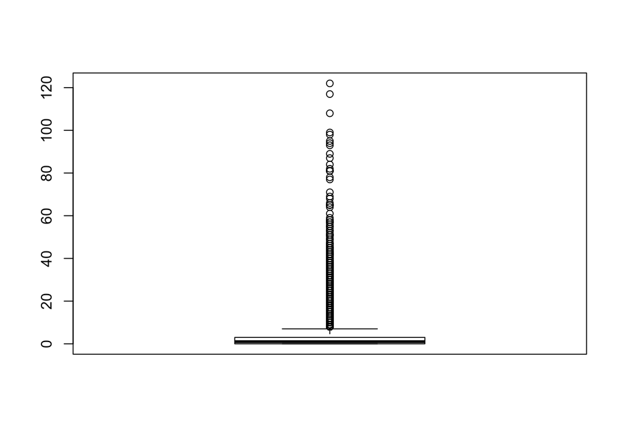

```r
boxplot(clothing$positive_feedback_count)
```

**Summary : From result above, we find posibilities for the outliers, but from our calculation, Sd value is around 6 ( my oppinion its still be tolerated), so the process may continue**

How much total of rating from each category, and which is the highest?

```r
aggregate(rating~category,clothing,sum)
```

| category | rating |
| --- | --- |
| Bottoms | 16293 |
| Dresses | 26229 |
| Intimate | 7426 |
| Jackets | 4401 |
| Tops | 43675 |
| Trend | 454 |

**Answer : highest rating comes from category from ‘tops’ in 43675 total ratings**

```r
aggregate(rating~category,clothing,sum)
```

| category | rating |
| --- | --- |
| Bottoms | 16293 |
| Dresses | 26229 |
| Intimate | 7426 |
| Jackets | 4401 |
| Tops | 43675 |
| Trend | 454 |

**Answer : lowest rating comes from category from ‘trend’ in 454 total ratings**

Which `product category` based on customer `age_group` gives the highest `positive_feedback_count`?

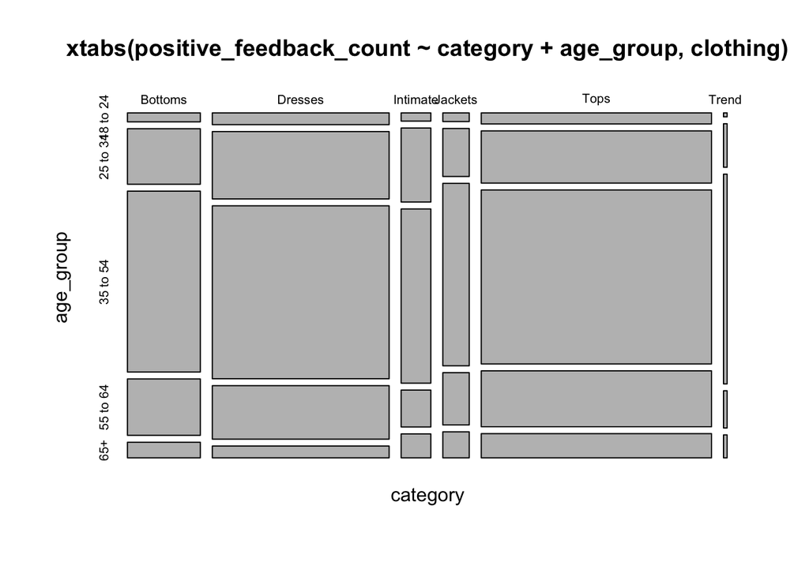

```r
plot(xtabs(positive_feedback_count~category + age_group,clothing))
```

**Answer : overalll based on `age_group` `35 to 54` and `positive feedback count` category `tops` is the most favourite of consuments**

Which category based on division_name that given the most positive feedback count?

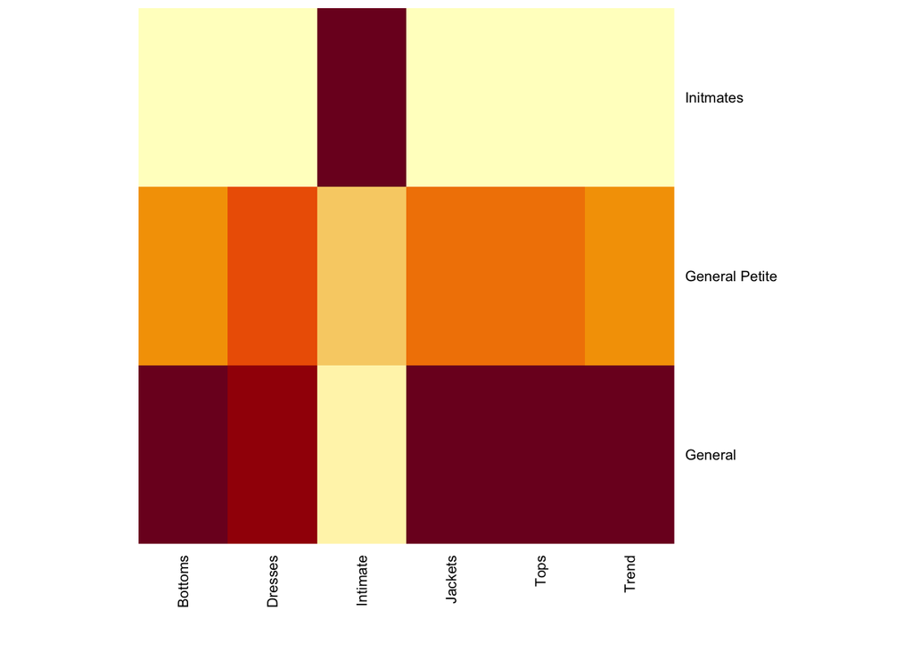

```r
heatmap(xtabs(positive_feedback_count~division_name+category, clothing), cexRow = 0.8, cexCol = 0.8, scale = "column", Colv = NA, Rowv = NA)
```

**Answer : the most lovable category of product is `General`**

In which month, the the consumer give the most rating to the product category (based division_names)?

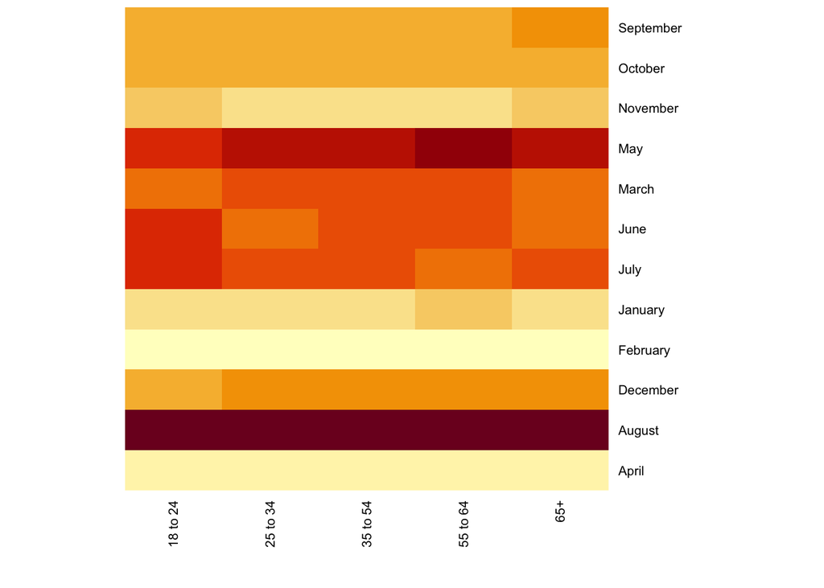

```r
# create month column
clothing$review_month <- months(clothing$review_date)

# create heatmap to visualize your data
heatmap(xtabs(rating  ~ review_month + age_group,clothing), cexRow = 0.8, cexCol = 0.8, scale = "column", Colv = NA, Rowv = NA)
```

**Answer : most of consuments give rating on `August`**

How was the rating activity based on, product category and division_names ?

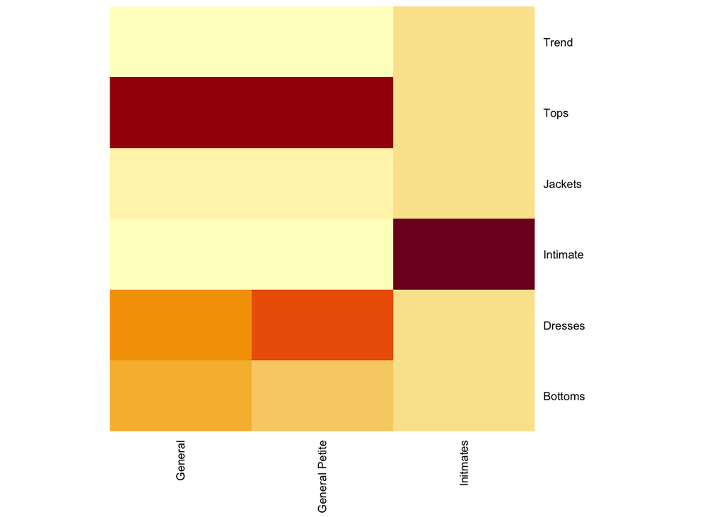

```r
# scale the consume rating
heatmap(xtabs(rating~category + division_name, clothing), cexRow = 0.8, cexCol = 0.8, scale = "column", Colv = NA, Rowv = NA)
```

**Answer : the highest rating based on division_name and category `General and General Petite` is `Tops` and for `Intimates` is `Intimate`**

What is the most recommended product based on the consumer’s vote?

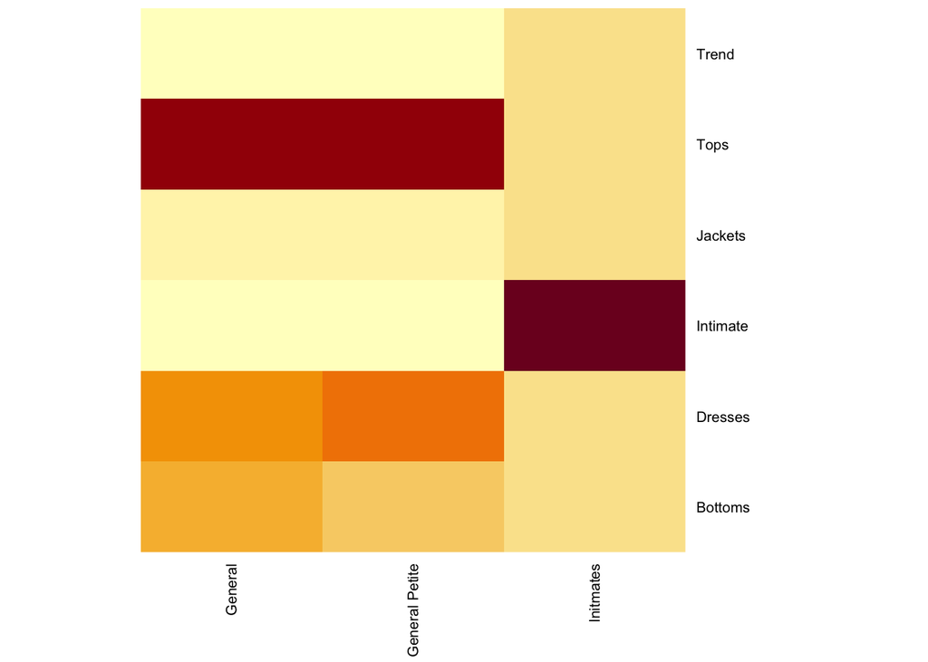

```r
# scale recommended product
heatmap(xtabs(recommended_ind ~ category + division_name, clothing), cexRow = 0.8, cexCol = 0.8, scale = "column", Colv = NA, Rowv = NA)
```

**Answer : the recommended product based on division_name and category `General and General Petite` is `Tops` and for `Intimates` is `Intimate`**

# 7 Explanatory Text & Business Recomendation

**Recommendations**

- Tops will still be the most lovable category products
- Brand General and General Petite produce good tops and Intimates produce good Intimate that like by consumers
- August is the month that consumer will leave comment by
- Age group 35 - 64 is the group that have a high engagement with the company
- Q1 is the food time for the company to push the rating especially for age group 25-34, 35-54, 55-64
- Most of highest rating product will be good to be recommended to the non-buyers